# Homework #1

## Goals

- Read each file and join them together.
- Create variables to capture the following ideas:
  - How long has the artist been around? You can just use their birth year.
  - Something to capture each artist’s net worth per studio album.
  - How old was each artist when they had their biggest hit?
- Which artist has been around the longest?
- Which artists are above the mean of net worth per studio album?
- Plot net worth per studio album, the “been around” variable, and genre. There should be points and colors here.
- Show me something. There is a nice chunk of data here and you’ve got to have some neat ideas!
- Comment and explain everything!

## Reading Files

**Solution**

```r
# reading files

artist_top_hits <- read.csv("~/Downloads/artist_top_hits.csv") %>%
  janitor::clean_names()

artist_albums <- read.csv("~/Downloads/artist_studio_albums.csv") %>%
  janitor::clean_names()

artist_one_hits <- read.csv("~/Downloads/artist_number_one_hits.csv") %>%
  janitor::clean_names()

artist_worth <- read.csv("~/Downloads/artist_net_worth.csv") %>%
  janitor::clean_names()

artist_name <- read.csv("~/Downloads/artist_name.csv") %>%
  janitor::clean_names()

artist_genre <- read.table("~/Downloads/artist_genre.txt", header = TRUE) %>%
  janitor::clean_names()
```

## Identifying and Removing Duplicated Artists

**Solution**

```r
# for the these data sets, 12 artists have duplicated rows appear more than once

# code that extracts artists who appear more than once in each data set

artist_name_duplicates <- data.frame(unique(artist_name$artist[duplicated(artist_name$artist)]))

artist_albums_duplicates <- data.frame(unique(artist_albums$artist[duplicated(artist_albums$artist)]))

artist_genre_duplicates <- data.frame(unique(artist_genre$artist[duplicated(artist_genre$artist)]))

artist_one_hits_duplicates <- data.frame(unique(artist_one_hits$artist[duplicated(artist_one_hits$artist)]))

artist_top_hits_duplicates <- data.frame(unique(artist_top_hits$artist[duplicated(artist_top_hits$artist)]))

artist_worth_duplicates <- data.frame(unique(artist_worth$artist[duplicated(artist_worth$artist)]))


# getting rid of rows to ensure artists only appear in one row in each dataset

artist_name <- artist_name[!duplicated(artist_name[c("artist")]), ]

artist_one_hits <- artist_one_hits[!duplicated(artist_one_hits[c("artist")]), ]

artist_top_hits <- artist_top_hits[!duplicated(artist_top_hits[c("artist")]), ]

artist_worth <- artist_worth[!duplicated(artist_worth[c("artist")]), ]

artist_albums <- artist_albums[!duplicated(artist_albums[c("artist")]), ]

artist_genre <- artist_genre[!duplicated(artist_genre[c("artist")]), ]
```

## Merging Data Sets

**Solution**

```r
# merging all data into one data frame

merged_artist <- merge(artist_albums, artist_genre, by = "artist")
merged_artist <- merge(merged_artist, artist_name, by = "artist")
merged_artist <- merge(merged_artist, artist_one_hits, by = "artist")
merged_artist <- merge(merged_artist, artist_top_hits, by = "artist")
merged_artist <- merge(merged_artist, artist_worth, by = "artist")
```

## Creating New Variables

**Solution**

```r
# creating age variable
merged_artist$age <- (2023 - merged_artist$birth_year)

# removing $ symbol from any value in the net worth column
merged_artist$net_worth_millions = gsub("\\$", "", merged_artist$net_worth_millions)

# creating net worth per studio album
merged_artist$net_worth_millions <- as.integer(merged_artist$net_worth_millions)

merged_artist$net_worth_per_album <-
  round(merged_artist$net_worth_millions / merged_artist$studio_albums, digits = 2)

# renaming year column to hit_year
colnames(merged_artist)[colnames(merged_artist) == "year"] = "hit_year"

# creating age at biggest hit variable
merged_artist$hit_age <- merged_artist$hit_year - merged_artist$birth_year
```

## Question 1

`What artist has "been around" the longest?`

**Solution**

```r
# finding artist who has "been around" the longest
oldest_artist_df <- merged_artist[order(merged_artist$birth_year),]

rmarkdown::paged_table(head(oldest_artist_df, 1))
```

|  | artist | studio_albums | genre | birth_year | number_one_hits | top_hit | hit_year | net_worth_millions | age | net_worth_per_album | hit_age |
| --- | --- | --- | --- | --- | --- | --- | --- | --- | --- | --- | --- |
| 22 | Frank Sinatra | 59 | Jazz/Pop | 1915 | 3 | My Way | 1969 | 200 | 108 | 3.39 | 54 |

###### Frank Sinatra has “been around” the longest.

## Question 2

`Which artists are above the mean of net worth per studio album?`

**Aolution**

```r
# creating avg_worth variable
avg_worth <- round(mean(merged_artist$net_worth_per_album), digits = 2)

# finding artists who qualify as having an above average net worth
above_avg_artists <- merged_artist$net_worth_per_album > avg_worth

# creating data frame of these names
high_worth_artists <- data.frame(merged_artist[above_avg_artists, ]$artist)

rmarkdown::paged_table(high_worth_artists)
```

| merged_artist.above_avg_artists....artist |
| --- |
| ABBA |
| Adele |
| Beyoncé |
| Bruno Mars |
| Coldplay |
| Drake |
| Ed Sheeran |
| George Michael |
| Jay-Z |
| Jimi Hendrix |

[output cut: 13 more lines]

###### The above artists have a greater net worth per album than the average net worth of 32.42 million.

## Question 3

`Plotting net worth per studio album, "been around" variable, and genre`

**Solution**

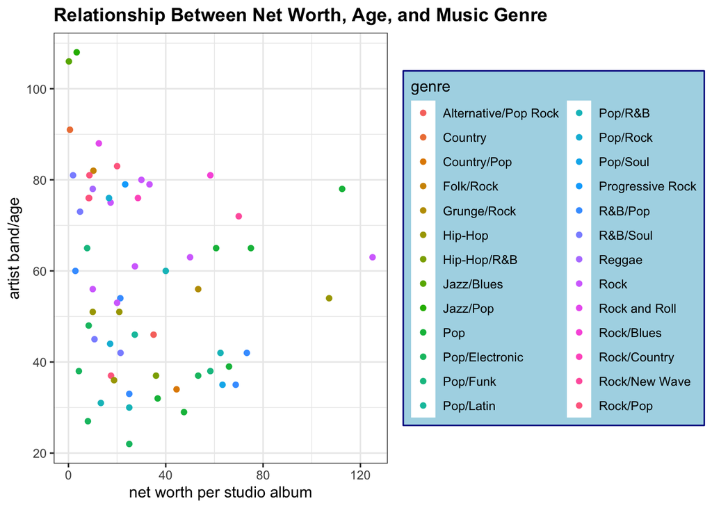

```r
library(ggplot2)

# creating scatter plot of net_worth_per_album compared to age, categorized by genre
age_album_plot <- ggplot(merged_artist, aes(x = net_worth_per_album, y = age, color = genre )) +
  geom_point() +
  theme_bw() +
  labs(x = "net worth per studio album",
       y = "artist band/age",
       title = "Relationship Between Net Worth, Age, and Music Genre") +
   theme(
    plot.title = element_text(face = "bold"),
    legend.background = element_rect(fill = "lightblue",
                                  linewidth = 0.5, linetype = "solid",
                                  color = "darkblue")
  )

age_album_plot
```

## Question 4

`Examining the relationship between net worth and music popularity`

**Solution**

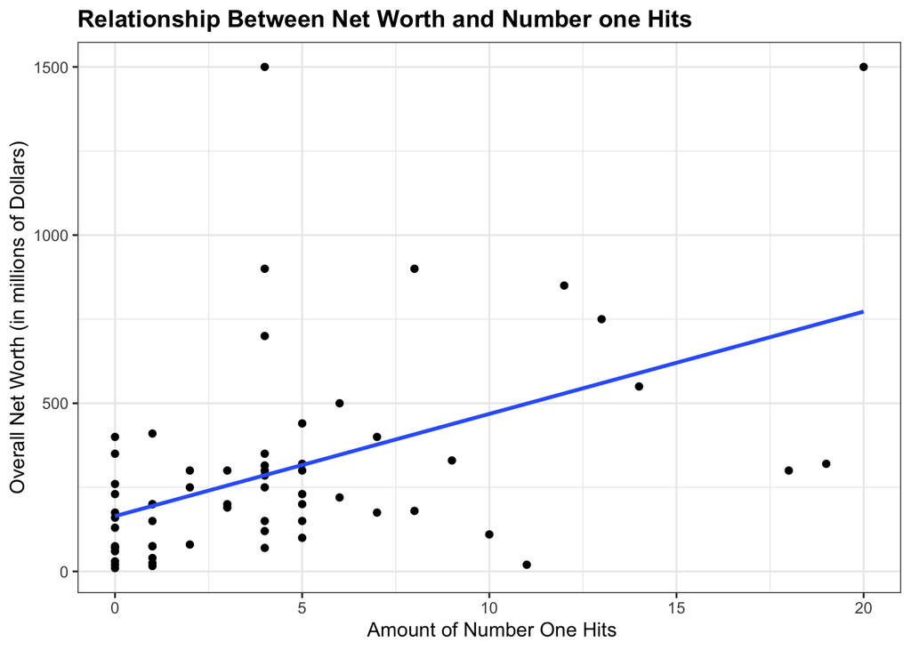

```r
# creating scatter plot examining the relationship betweeen number of #1 hits and net worth

worth_hits_plot <- ggplot(merged_artist, aes(x = number_one_hits, y = net_worth_millions)) +
  geom_point() +
  geom_smooth(method = "lm", se = FALSE) +
  theme_bw() +
  labs(y = "Overall Net Worth (in millions of Dollars)",
       x = "  Amount of Number One Hits ",
       title = "Relationship Between Net Worth and Number one Hits") +
   theme(
    plot.title = element_text(face = "bold")
  )

worth_hits_plot
```

###### In general, artists who have more number one hits generate a higher net worth for themselves